# Validate sd_bounds() / brimmer(): paths, sweeps, and the joint blind spot of GRIM + GRIMMER + bounds

Author

Ian Hussey

```r
# These tidyverse/unsum packages are used only by this dev-time validation
# document (which is excluded from the build via .Rbuildignore); they are NOT
# runtime dependencies of the package.
library(dplyr)
library(tidyr)
library(purrr)
library(tibble)
library(ggplot2)
library(knitr)
library(scrutiny)
library(unsum)

# Dev-time validation: load the package under development from the repo root.
# (This document lives in validation/, which is excluded from the build via
# .Rbuildignore, so it is never run by R CMD check.)
if (requireNamespace("pkgload", quietly = TRUE)) {
  pkgload::load_all("..", quiet = TRUE)
} else {
  library(strait)
}

ok_tally <- list()
check <- function(ok, label) {
  ok_tally[[label]] <<- isTRUE(ok)
  invisible(ok)
}
```

# Part 1: validated paths

## Exact path vs exhaustive enumeration

Every integer sample for $n \in \{3,4,5\}$ on scales 1–4 and 1–5 is enumerated; `sd_bounds()` must reproduce the exact achievable min and max SD for every (constraint set, sum) cell: walls, attained extremes, and the two mixed cases.

```r
n_bad <- 0; n_cells <- 0
for (n in 3:5) for (u0 in c(4, 5)) {
  l0 <- 1
  g <- as.matrix(do.call(expand.grid, rep(list(l0:u0), n)))
  S <- rowSums(g); sdv <- apply(g, 1, sd)
  mn <- apply(g, 1, min); mx <- apply(g, 1, max)

  for (s0 in unique(S)) {
    i <- S == s0; m <- s0 / n; n_cells <- n_cells + 1
    r <- sd_bounds(l = l0, u = u0, n = n, mean = m, Z = "integer")
    if (!(r$feasible && abs(r$min_sd - min(sdv[i])) < 1e-9 &&
          abs(r$max_sd - max(sdv[i])) < 1e-9)) n_bad <- n_bad + 1
    # quasi floor equals the integer floor at GRIM-consistent means
    rq <- sd_bounds(l = l0, u = u0, n = n, mean = m, Z = "quasiinteger")
    if (abs(rq$min_sd - r$min_sd) > 1e-9) n_bad <- n_bad + 1
  }
  # attained both extremes
  for (aa in l0:(u0 - 1)) for (bb in (aa + 1):u0) {
    j <- mn == aa & mx == bb
    if (!any(j)) next
    for (s0 in unique(S[j])) {
      i <- j & S == s0; n_cells <- n_cells + 1
      r <- sd_bounds(a = aa, b = bb, n = n, mean = s0 / n, Z = "integer")
      if (!(r$feasible && abs(r$min_sd - min(sdv[i])) < 1e-9 &&
            abs(r$max_sd - max(sdv[i])) < 1e-9)) n_bad <- n_bad + 1
    }
  }
  # mixed: wall + one attained extreme (both mirrors)
  for (bb in (l0 + 1):u0) {
    j <- mx == bb
    for (s0 in unique(S[j])) {
      i <- j & S == s0; n_cells <- n_cells + 1
      r <- sd_bounds(l = l0, b = bb, n = n, mean = s0 / n, Z = "integer")
      if (!(r$feasible && abs(r$min_sd - min(sdv[i])) < 1e-9 &&
            abs(r$max_sd - max(sdv[i])) < 1e-9)) n_bad <- n_bad + 1
    }
  }
  for (aa in l0:(u0 - 1)) {
    j <- mn == aa
    for (s0 in unique(S[j])) {
      i <- j & S == s0; n_cells <- n_cells + 1
      r <- sd_bounds(a = aa, u = u0, n = n, mean = s0 / n, Z = "integer")
      if (!(r$feasible && abs(r$min_sd - min(sdv[i])) < 1e-9 &&
            abs(r$max_sd - max(sdv[i])) < 1e-9)) n_bad <- n_bad + 1
    }
  }
}
check(n_bad == 0, sprintf("exact path == enumeration (%d cells)", n_cells))
kable(tibble(cells_tested = n_cells, mismatches = n_bad),
      caption = "Exact-mean bounds vs exhaustive enumeration, all constraint states.")
```

Exact-mean bounds vs exhaustive enumeration, all constraint states.

| cells_tested | mismatches |
| --- | --- |
| 648 | 0 |

## Rounding layer: envelopes and open endpoints

```r
res_round <- list()

# envelope == brute scan (quasi-integer and continuous)
for (Zi in c("quasiinteger", "continuous")) {
  r <- sd_bounds(l = 1, u = 7, n = 30, mean = 2.97, mean_digits = 2,
                 rounding = "up_or_down", Z = Zi)
  ms <- seq(2.965, 2.975, length.out = 5001)
  fl <- vapply(ms, function(m) sd_bounds(l = 1, u = 7, n = 30, mean = m, Z = Zi)$min_sd, 1)
  cl <- vapply(ms, function(m) sd_bounds(l = 1, u = 7, n = 30, mean = m, Z = Zi)$max_sd, 1)
  res_round[[paste0(Zi, " envelope")]] <-
    abs(r$min_sd - min(fl)) < 1e-6 && abs(r$max_sd - max(cl)) < 1e-6
}

# strict integer: GRIM means enumerated exactly; open endpoints respected
# n = 20, mean 2.4 to 1 dp: candidates 2.35, 2.40, 2.45 sit ON the interval edges
r_uod <- sd_bounds(n = 20, mean = 2.4, mean_digits = 1, rounding = "up_or_down", Z = "integer")
r_up  <- sd_bounds(n = 20, mean = 2.4, mean_digits = 1, rounding = "up",         Z = "integer")
r_dn  <- sd_bounds(n = 20, mean = 2.4, mean_digits = 1, rounding = "down",       Z = "integer")
res_round[["closed endpoints (up_or_down)"]] <- abs(r_uod$min_sd - sd_min_integer(2.35, 20)) < 1e-9
res_round[["open upper endpoint (up)"]]      <- abs(r_up$min_sd  - sd_min_integer(2.35, 20)) < 1e-9
res_round[["open lower endpoint (down)"]]    <- abs(r_dn$min_sd  - sd_min_integer(2.40, 20)) < 1e-9

# truncation option
iv <- unround_interval(2.97, 2, "trunc")
res_round[["trunc interval [x, x+unit)"]] <- abs(iv$lo - 2.97) < 1e-12 && !iv$hi_incl

for (nm in names(res_round)) check(res_round[[nm]], nm)
kable(tibble(test = names(res_round), passed = unlist(res_round)),
      caption = "Rounding layer.")
```

Rounding layer.

| test | passed |
| --- | --- |
| quasiinteger envelope | TRUE |
| continuous envelope | TRUE |
| closed endpoints (up_or_down) | TRUE |
| open upper endpoint (up) | TRUE |
| open lower endpoint (down) | TRUE |
| trunc interval [x, x+unit) | TRUE |

## scrutiny deference, including the documented-bug witness

GRIM and GRIMMER verdicts are deferred to scrutiny and reported verbatim. scrutiny’s GRIMMER has documented false-flag cases (see `scrutiny_grimmer_issue_draft.md` in this folder); the witness dataset `c(rep(1, 7), rep(0, 193))` produces mean 0.035 and SD 0.184, reported as (0.03, 0.18), which scrutiny flags — while feasibility and the bounds check correctly admit it.

```r
res_scr <- list()

r <- sd_bounds(l = 0, u = 1, n = 200, mean = 0.03, mean_digits = 2,
               sd = 0.18, sd_digits = 2, rounding = "up_or_down", Z = "integer")
res_scr[["witness: feasible & sd_in_bounds TRUE"]] <- r$feasible && isTRUE(r$sd_in_bounds)
res_scr[["witness: scrutiny grimmer FALSE (documented false flag)"]] <- isFALSE(r$grimmer)

# GRIMMER is scale-free; the bounds check is the complementary test
r2 <- sd_bounds(l = 1, u = 7, n = 30, mean = 2.97, mean_digits = 2,
                sd = 3.30, sd_digits = 2, rounding = "up_or_down", Z = "integer")
res_scr[["sd above ceiling: sd_in_bounds FALSE"]] <- isFALSE(r2$sd_in_bounds)

# divergence note fires when scrutiny disagrees with the internal enumeration
r3 <- sd_bounds(l = 0, u = 1, n = 40, mean = 0.07, mean_digits = 2,
                rounding = "up", Z = "integer")
res_scr[["documented grim false pass surfaces divergence note"]] <-
  !r3$feasible && isTRUE(r3$grim) && grepl("disagrees", r3$note)

for (nm in names(res_scr)) check(res_scr[[nm]], nm)
kable(tibble(test = names(res_scr), passed = unlist(res_scr)),
      caption = "scrutiny deference.")
```

scrutiny deference.

| test | passed |
| --- | --- |
| witness: feasible & sd_in_bounds TRUE | TRUE |
| witness: scrutiny grimmer FALSE (documented false flag) | TRUE |
| sd above ceiling: sd_in_bounds FALSE | TRUE |
| documented grim false pass surfaces divergence note | TRUE |

## GRIMMER misses in the CRAN release of scrutiny

The witness above is a *documented* false flag. There is a second, broader one that matters more for anyone installing this package today. scrutiny 0.6.1 — the current CRAN release, and therefore what CRAN builds `strait` against — carries a bug in GRIMMER’s third test that flags attainable values as inconsistent (https://github.com/lhdjung/scrutiny/issues/80); it warns about this on every call. The development version (0.6.2) fixes it.

This matters because `brimmer()`, `umbrella_data()` and the lattice rules defer to scrutiny verbatim and so inherit the false flags. `brimmest()` does not defer to anything, and disproves them constructively.

```r
scrutiny_ver <- as.character(packageVersion("scrutiny"))

# a real dataset: 12 integers on 1-5, exact mean 1.25 -> "1.2" (halves down),
# exact SD 0.4523 -> "0.5". Any test calling this report impossible is wrong.
witness <- c(rep(1, 9), 2, 2, 2)
w_ok <- length(witness) == 12 && all(witness == round(witness) &
                                     witness >= 1 & witness <= 5)
w_cert <- brimmest(l = 1, u = 5, n = 12, mean = 1.2, sd = 0.5, digits = 1)

# how many cells does the installed scrutiny reject that brimmest() proves real?
um_g <- umbrella_data(n = 12, l = 1, u = 5, digits = 1, Z = "integer")
cert_g <- brimmest(l = 1, u = 5, n = 12, mean = um_g$mean, sd = um_g$sd,
                  digits = 1)
misses <- which(!um_g$consistent & cert_g$possible)

cat(sprintf("installed scrutiny: %s\n", scrutiny_ver))
```

```
installed scrutiny: 0.6.2
```

```r
cat(sprintf("witness c(rep(1, 9), 2, 2, 2): n = %d, mean = %.4f, sd = %.4f\n",
            length(witness), mean(witness), sd(witness)))
```

```
witness c(rep(1, 9), 2, 2, 2): n = 12, mean = 1.2500, sd = 0.4523
```

```r
cat(sprintf("brimmest() calls the report (1.2, 0.5) possible: %s (rules: %s)\n",
            w_cert$possible, w_cert$rules))
```

```
brimmest() calls the report (1.2, 0.5) possible: TRUE (rules: half_down)
```

```r
cat(sprintf("cells the screen rejects but brimmest() proves attainable: %d of %d\n",
            length(misses), nrow(um_g)))
```

```
cells the screen rejects but brimmest() proves attainable: 0 of 684
```

```r
if (length(misses)) {
  cat("  all are inside the SD bounds, so GRIMMER alone is rejecting them: ",
      all(um_g$in_bounds[misses]), "\n", sep = "")
  print(utils::head(tibble(mean = um_g$mean[misses], sd = um_g$sd[misses],
                           grimmer = um_g$grimmer[misses], certified = TRUE), 5))
}

# The witness is real, so this must hold on every scrutiny version.
check(w_ok && isTRUE(w_cert$possible),
      "brimmest() admits a hand-constructed integer witness")
# Version-dependent, so recorded rather than asserted: it is a property of the
# installed scrutiny, not of this package.
cat(sprintf("\n=> On scrutiny %s, strait's GRIMMER-dependent verdicts are %s.\n",
            scrutiny_ver,
            if (length(misses)) "AFFECTED by the upstream bug" else "clean"))
```

```
=> On scrutiny 0.6.2, strait's GRIMMER-dependent verdicts are clean.
```

Until scrutiny 0.6.2 reaches CRAN, GRIMMER verdicts from a CRAN install should be read alongside `brimmest()`, and this package should not be submitted to CRAN — a forensic tool that false-flags legitimate reports is worse than one that is merely slow. See the TODO in `README.md`.

## brimmer(): verdict paths

```r
paths <- tribble(
  ~scenario, ~call,
  "ordinary report (witnessed by c(rep(1,20), rep(7,9), 6))",
    quote(brimmer(l = 1, u = 7, n = 30, mean = 2.97, mean_digits = 2,
                          sd = 2.83, sd_digits = 2, Z = "integer")),
  "SD below the quasi-integer floor",
    quote(brimmer(l = 1, u = 7, n = 30, mean = 2.97, mean_digits = 2,
                          sd = 0.10, sd_digits = 2, Z = "quasiinteger")),
  "SD above the ceiling",
    quote(brimmer(l = 1, u = 7, n = 30, mean = 2.97, mean_digits = 2,
                          sd = 3.30, sd_digits = 2, Z = "integer")),
  "GRIM-impossible mean",
    quote(brimmer(l = 1, u = 7, n = 30, mean = 3.51, mean_digits = 2,
                          sd = 1.00, sd_digits = 2, Z = "integer")),
  "scrutiny false-flag witness (only grimmer fails)",
    quote(brimmer(l = 0, u = 1, n = 200, mean = 0.03, mean_digits = 2,
                          sd = 0.18, sd_digits = 2, Z = "integer")),
  "mean-free: SD at the parity ceiling",
    quote(brimmer(l = 1, u = 7, n = 10, sd = 3.16, sd_digits = 2, Z = "integer")),
  "attained extremes: SD below the two-pin floor",
    quote(brimmer(a = 1, b = 7, n = 10, mean = 4.0, mean_digits = 1,
                          sd = 1.20, sd_digits = 2, Z = "integer"))
)
verdicts <- paths |>
  rowwise() |>
  mutate(res = list(eval(call)),
         consistent = res$consistent, failed_tests = res$failed_tests,
         min_sd = round(res$min_sd, 3), max_sd = round(res$max_sd, 3)) |>
  ungroup() |>
  select(-call, -res)

expected <- c(TRUE, FALSE, FALSE, FALSE, FALSE, TRUE, FALSE)
check(identical(verdicts$consistent, expected), "brimmer verdict paths")
kable(verdicts, caption = "Verdict paths. The witness row is inconsistent solely through scrutiny's documented GRIMMER false flag; its note carries the caveat.")
```

Verdict paths. The witness row is inconsistent solely through scrutiny’s documented GRIMMER false flag; its note carries the caveat.

| scenario | consistent | failed_tests | min_sd | max_sd |
| --- | --- | --- | --- | --- |
| ordinary report (witnessed by c(rep(1,20), rep(7,9), 6)) | TRUE |  | 0.183 | 2.834 |
| SD below the quasi-integer floor | FALSE | bounds | 0.137 | 2.844 |
| SD above the ceiling | FALSE | bounds | 0.183 | 2.834 |
| GRIM-impossible mean | FALSE | grim,grimmer | NA | NA |
| scrutiny false-flag witness (only grimmer fails) | FALSE | grimmer | 0.157 | 0.184 |
| mean-free: SD at the parity ceiling | TRUE |  | 0.000 | 3.162 |
| attained extremes: SD below the two-pin floor | FALSE | bounds,grimmer | 1.414 | 3.162 |

# Part 2: the complete discrete umbrella (Fünderich enumeration)

Fünderich et al. (2025) treat rating-scale data as allocations across the scale points, with the extremal configurations Bernoulli-like two-point distributions. For fixed $(n, l, u)$ this makes the set of achievable $(M, SD)$ pairs finite: enumerate every frequency vector (composition of $n$ over the $u - l + 1$ scale points), exactly as CLOSURE does, and compute each one’s mean and SD.

```r
n_u <- 12; l_u <- 1; u_u <- 5

compositions <- function(n, k) {
  if (k == 1) return(matrix(n, 1, 1))
  do.call(rbind, lapply(0:n, function(i) cbind(i, compositions(n - i, k - 1))))
}
Cm <- compositions(n_u, u_u - l_u + 1)
vals <- l_u:u_u
S_all  <- as.vector(Cm %*% vals)
Q_all  <- as.vector(Cm %*% (vals^2))
SS_all <- Q_all - S_all^2 / n_u
umbrella <- tibble(S = S_all, SS = round(SS_all, 9)) |>
  distinct() |>
  mutate(mean = S / n_u, sd = sqrt(SS / (n_u - 1)))

cat(sprintf("n = %d on %d-%d: %s frequency vectors -> %s distinct achievable (M, SD) pairs\n",
            n_u, l_u, u_u, format(nrow(Cm), big.mark = ","),
            format(nrow(umbrella), big.mark = ",")))
```

```
n = 12 on 1-5: 1,820 frequency vectors -> 655 distinct achievable (M, SD) pairs
```

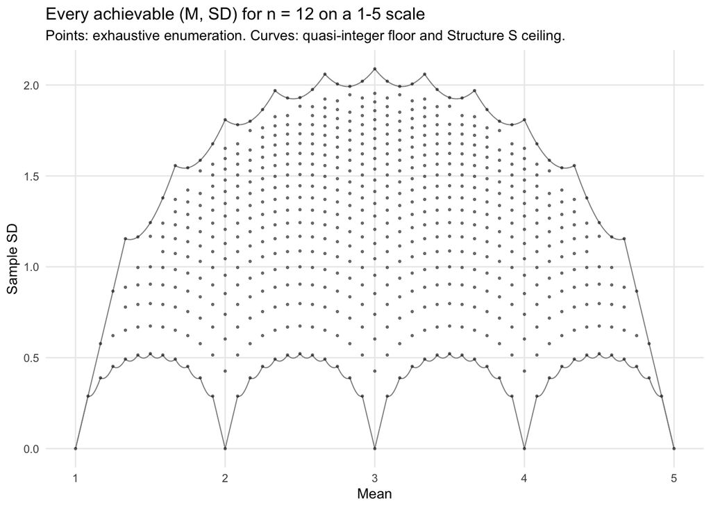

```r
# the umbrella must respect the sd_bounds primitives at every attainable mean
env_ok <- umbrella |>
  mutate(ceil = sd_max_structure_s(mean, n_u, l_u, u_u),
         flr  = sd_min_integer(mean, n_u)) |>
  summarise(all(sd <= ceil + 1e-9) && all(sd >= flr - 1e-9)) |>
  pull()
check(env_ok, "umbrella inside [integer floor, Structure S ceiling]")

# Sharpness, which is the stronger claim: the bounds are not merely respected
# by the enumeration, they are ATTAINED by it. At every attainable mean the
# largest enumerated SD equals the Structure S ceiling and the smallest equals
# the integer floor, so neither bound can be tightened. (Earlier drafts of this
# validation compared the envelope against CLOSURE cell by cell to establish
# the same thing; enumerating directly is exact and far cheaper.)
sharp <- umbrella |>
  group_by(mean) |>
  summarise(hi = max(sd), lo = min(sd), .groups = "drop") |>
  mutate(ceil = sd_max_structure_s(mean, n_u, l_u, u_u),
         flr  = sd_min_integer(mean, n_u))
check(all(abs(sharp$hi - sharp$ceil) < 1e-9),
      "Structure S ceiling ATTAINED at every attainable mean (sharp above)")
check(all(abs(sharp$lo - sharp$flr) < 1e-9),
      "integer floor ATTAINED at every attainable mean (sharp below)")

grid_env <- tibble(mean = seq(l_u, u_u, by = 0.002),
                   lo = sd_min_quasi_integer(mean, n_u),
                   hi = sd_max_structure_s(mean, n_u, l_u, u_u))

ggplot(umbrella, aes(mean, sd)) +
  geom_line(data = grid_env, aes(mean, hi), colour = "grey55", linewidth = 0.35) +
  geom_line(data = grid_env, aes(mean, lo), colour = "grey55", linewidth = 0.35) +
  geom_point(size = 0.5, alpha = 0.5) +
  scale_x_continuous("Mean", breaks = l_u:u_u) +
  scale_y_continuous("Sample SD") +
  labs(title = sprintf("Every achievable (M, SD) for n = %d on a %d-%d scale", n_u, l_u, u_u),
       subtitle = "Points: exhaustive enumeration. Curves: quasi-integer floor and Structure S ceiling.") +
  theme_minimal(base_size = 10) +
  theme(panel.grid.minor = element_blank())
```

The achievable pairs form the familiar discrete umbrella; the closed-form envelope traces its outline exactly, with the points thinning toward the edges — the thinning that produces the blind spot below.

# Part 3: the joint blind spot

**How achievability is certified.** Two independent, exhaustive methods, which must agree. (i) The composition enumeration of Part 2 *is* a from-scratch CLOSURE: every frequency vector for $(n, l, u)$ is an integer dataset (up to a permutation that leaves $M$ and $SD$ unchanged), so the set of achievable $(M, SD)$ is complete, and a reported tuple is achievable iff some enumerated exact pair’s mean and SD both unround to it. (ii) The established `unsum::closure()` (Bartos & Nguyen’s exact enumerator) is run on every tuple this document flags as unachievable, and on a matched sample of achievable ones; `samples_all` is the count of integer datasets it finds. A false-pass claim stands only when *both* say zero. The two are diffed cell by cell below.

**Claim.** There exist reported 2-dp $(M, SD)$ tuples that pass GRIM, pass GRIMMER, and pass the bounds check, yet correspond to **no** integer dataset — even if all three tests were implemented perfectly. They must be few, and they must sit at the very top edge of the umbrella.

**Why they must exist.** The three tests see different shadows of the joint problem. GRIM tests the mean alone. GRIMMER tests the mean-SD pair through the existence, parity, and round-back of an integer sum of squares — but it is **scale-free**: it never learns $l$ and $u$, so it cannot know that the required sum of squares, while arithmetically fine, demands observations outside the limits. The bounds check knows the limits, but tests only that the SD lies inside the envelope — and just below the ceiling the achievable sums of squares have genuine gaps (the parity-contiguity failure exhibited in `inverse_bounds_min_max_range.qmd`): near the extremal U-shaped configurations, consecutive achievable sums of squares skip values, so thin slivers inside the envelope contain no integer solution. A reported tuple landing in such a sliver passes all three tests. Because the gaps open up only near the extremal configurations, the false passes are pinned to the top fringe of the umbrella, all along the arch.

```r
# ground truth: a reported (m2, s2) is achievable iff some enumerated exact
# pair lies within both up_or_down rounding intervals
half <- 0.005 + 1e-9

# sweep all GRIM-consistent reported means, SDs across the envelope +/- margin
rep_means <- sort(unique(round(unique(umbrella$mean), 2)))
sweep <- map_dfr(rep_means, function(m2) {
  r_env <- sd_bounds(l = l_u, u = u_u, n = n_u, mean = m2, mean_digits = 2,
                     rounding = "up_or_down", Z = "integer")
  if (!r_env$feasible) return(NULL)
  s2s <- seq(max(0, floor((r_env$min_sd - 0.03) * 100) / 100),
             r_env$max_sd + 0.03, by = 0.01)
  tibble(m2 = m2, s2 = round(s2s, 2))
})

sweep <- sweep |>
  rowwise() |>
  mutate(
    truth   = any(abs(umbrella$mean - m2) <= half & abs(umbrella$sd - s2) <= half),
    grim_p  = isTRUE(as.logical(unname(scrutiny::grim(x = m2, n = n_u, digits_x = 2)))[1]),
    grimmer_p = isTRUE(as.logical(unname(scrutiny::grimmer(x = m2, sd = s2, n = n_u,
                                                           digits_x = 2, digits_sd = 2)))[1]),
    bchk    = list(brimmer(l = l_u, u = u_u, n = n_u,
                                   mean = m2, mean_digits = 2,
                                   sd = s2, sd_digits = 2, Z = "integer")),
    bounds_p = isTRUE(bchk$feasible) && isTRUE(bchk$sd_in_bounds)
  ) |>
  ungroup() |>
  select(-bchk) |>
  mutate(all_pass = grim_p & grimmer_p & bounds_p)

kable(sweep |> count(truth, all_pass),
      caption = "Sweep of reported 2-dp (M, SD) tuples: ground truth (an integer dataset exists) against passing all three tests.")
```

Sweep of reported 2-dp (M, SD) tuples: ground truth (an integer dataset exists) against passing all three tests.

| truth | all_pass | n |
| --- | --- | --- |
| FALSE | FALSE | 5141 |
| FALSE | TRUE | 54 |
| TRUE | TRUE | 655 |

```r
false_pass <- sweep |> filter(all_pass & !truth)
false_flag <- sweep |> filter(!all_pass & truth)
check(nrow(false_flag) == 0, "no false flags (truth achievable but some test fails)")
check(nrow(false_pass) > 0, "false passes exist (the blind spot is real)")
check(nrow(false_pass) / sum(sweep$all_pass) < 0.10,
      "false passes are few (< 10% of passing tuples; ~8% at this coarse n)")
```

```r
# where do the false passes sit? all are INTERIOR gaps: inside the strict
# [min, max] at their mean, but with no achievable SD nearby - and all in the
# top fringe of the umbrella, just below the strict ceiling
fringe <- false_pass |>
  rowwise() |>
  mutate(
    t_near = list(unique(umbrella$S[abs(umbrella$mean - m2) <= half])),
    sd_strict_max = max(umbrella$sd[umbrella$S %in% t_near]),
    d_nearest = min(abs(umbrella$sd[umbrella$S %in% t_near] - s2)),
    rel_height = s2 / sd_strict_max
  ) |>
  ungroup() |>
  select(m2, s2, sd_strict_max, d_nearest, rel_height)

kable(
  tibble(
    `false passes` = nrow(fringe),
    `distinct means affected` = length(unique(fringe$m2)),
    `min relative height (s2 / strict max at that mean)` = round(min(fringe$rel_height), 3),
    `median relative height` = round(median(fringe$rel_height), 3),
    `max gap to nearest achievable SD` = round(max(fringe$d_nearest), 3)
  ),
  caption = "Location of every false pass. None lies beyond the strict achievable range at its mean; all sit in interior achievability gaps concentrated in the top fringe of the umbrella (median relative height ~0.9), spread along the whole arch (1-2 per GRIM-consistent mean)."
)
```

| false passes | distinct means affected | min relative height (s2 / strict max at that mean) | median relative height | max gap to nearest achievable SD |
| --- | --- | --- | --- | --- |
| 54 | 43 | 0.849 | 0.956 | 0.116 |

```r
check(all(fringe$rel_height > 0.75),
      "all false passes in the top fringe (relative height > 0.75)")
check(all(fringe$s2 <= fringe$sd_strict_max + 1e-9),
      "no false pass exceeds the strict achievable maximum at its mean")
```

## How close to the ceiling can a false pass hide? The gap ladder

CLOSURE need not run on every passing tuple. The achievability gaps that create false passes exist *only* near the maximum-spread configurations, i.e. hugging the ceiling; a tuple well below it has a large fibre and is trivially achievable, so the (slowest) CLOSURE call there is wasted. To prune we need to know **how far below the ceiling a false pass can sit** — and that has a derivation, not a magic number.

At a fixed integer mean the achievable SDs form a ladder down from the integer maximum $s_{\max}(l,u,n,\bar{x},\mathbb{Z})$ (the Structure-S ceiling; the top of the ladder, since at a GRIM-consistent mean its remainder observation is itself an integer). The **top gap** — from $s_{\max}(l,u,n,\bar{x},\mathbb{Z})$ to the second-highest achievable SD — is, for even $n$ at the midpoint mean, obtained by one inward unit transfer ($l,u \to l{+}1,u{-}1$, which drops the summed squared deviation by $2(R-1)$):

$$g_1 \;=\; \frac{2(R-1)}{R\,\sqrt{n(n-1)}}, \qquad R = u - l.$$

Two consequences.

**The role of $d$ (reporting precision).** Notice $g_1$ has no $d$ in it — the gap between the top two achievable SDs is a property of the integer geometry ($n$ and $R$), not of how the number was printed. $d$ enters only as the **resolution** the gap is compared against: a reported value carries an uncertainty of half-width $\tfrac{1}{2}10^{-d}$, so it can fall cleanly *inside* a gap — landing on no achievable SD — only when the gap exceeds one reporting unit, $10^{-d}$. So $d$ does not move the ladder; it sets how fine a gap has to be resolved before a report can slip into it. It acts in three places:

- **Existence.** False passes exist *at all* only when the top gap clears the resolution, $g_1 > 10^{-d}$, i.e. $n \lesssim \tfrac{2(R-1)}{R}\,10^{d} \approx 2\cdot 10^{d}$ — about $n \lesssim 167$ for two-dp reporting on a 1–7 scale, and scaling by a full order of magnitude in $n$ per extra reported digit. Above that even the top gap is sub-resolution and there are essentially no false passes.
- **Depth.** Finer reporting (larger $d$) resolves smaller gaps, so the false-pass region reaches further down the ladder; coarser reporting confines it to the very top rungs. This is the $d$-dependence of the un-closed-form $K$.
- **Margin.** The prune threshold is quoted with one reporting unit $10^{-d}$ of slack, since a reported value stands for its whole rounding interval.

The band width itself, $C\,g_1$ with $C = 3$, is an empirical envelope **calibrated at $d = 2$** (the usual case). Because depth grows with $d$, a much finer $d$ could push false passes past $3\,g_1$; that is exactly what the retained-every-false-pass assertion guards against — it would fail and force a larger $C$ (or a $d$-aware $C$) rather than silently mis-prune.

**Depth (K) has no clean closed form.** How many rungs down the false-pass region reaches is *not* a formula: at two-dp resolution the achievable SDs are never dense (the minimum SD gap $\approx 1/[s(n-1)]$ already exceeds $10^{-2}$ for realistic $s, n$), so there is no “dense region” boundary to solve for. Which of the wide gaps actually host a false pass depends on the interaction of the sum-of-squares parity/round-back structure (what GRIMMER tests) with the reporting grid — genuinely number-theoretic. Empirically the depth is small and grows with $R$: about the top 2–3 rungs at 1–5, top ~5 at 1–7, more on wide scales, shrinking with $n$.

So we do not parameterise a fixed $K$ or a fixed SD slab. Instead we compute the top gap $g_1$ *exactly per mean* from the ladder (which handles odd $n$ and the remainder automatically) and set the band at a small multiple of it:

$$\text{run CLOSURE iff}\quad s \;\ge\; s_{\max}(l,u,n,\bar{x},\mathbb{Z}) - C\cdot g_1,\qquad C = 3,$$

with the convention that if $g_1 < 10^{-d}$ (no wide gap) the band is empty. The constant $C = 3$ absorbs the un-closed-form depth; it is calibrated so that every false pass is retained, and — crucially — the retention is **asserted** from the exhaustive enumeration, so if $C$ is ever too small at some $(n, l, u)$ the render fails rather than silently mis-pruning.

```r
# Top achievable summed-squared-deviations at a fixed integer mean, via best-
# first search from the Structure-S maximum config using inward unit transfers.
# Complete for the top rungs, which is all the threshold needs.
top_ss_ladder <- function(n, l, u, S, depth = 3, guard_max = 20000) {
  R <- u - l; ex <- S - n * l
  if (ex < 0 || ex > n * R) return(numeric(0))
  nu <- ex %/% R; rem <- ex - nu * R
  cfg <- if (rem == 0) sort(c(rep(l, n - nu), rep(u, nu)))
         else          sort(c(rep(l, n - nu - 1), l + rem, rep(u, nu)))
  key <- function(v) paste(v, collapse = ","); Qof <- function(v) sum(v^2)
  seen <- new.env(hash = TRUE); assign(key(cfg), TRUE, envir = seen)
  frontier <- list(cfg); Qseen <- numeric(0); guard <- 0
  while (length(frontier) && length(unique(Qseen)) < depth && guard < guard_max) {
    guard <- guard + 1
    Qs <- vapply(frontier, Qof, 0); i <- which.max(Qs)
    v <- frontier[[i]]; frontier[[i]] <- NULL; Qseen <- c(Qseen, Qof(v))
    uq <- sort(unique(v))
    for (a in uq) for (b in uq) if (b - a >= 2) {
      w <- v; w[which(w == a)[1]] <- a + 1; w[which(w == b)[1]] <- b - 1; w <- sort(w)
      k <- key(w)
      if (!exists(k, envir = seen, inherits = FALSE)) {
        assign(k, TRUE, envir = seen); frontier[[length(frontier) + 1]] <- w
      }
    }
  }
  Q <- sort(unique(Qseen), decreasing = TRUE)
  (Q - S^2 / n)[seq_len(min(depth, length(Q)))]
}

# SD threshold below which no false pass can hide (ceiling minus C top-gaps).
ladder_threshold <- function(mean, n, l, u, digits, C = 3) {
  S <- round(n * mean); ss <- top_ss_ladder(n, l, u, S, depth = 3)
  if (length(ss) < 2) return(-Inf)                  # degenerate: check everything
  sd <- sqrt(pmax(0, ss) / (n - 1)); g1 <- sd[1] - sd[2]
  if (g1 < 10^(-digits)) return(sd[1])              # no wide gap -> no false passes
  sd[1] - C * g1
}
```

```r
fmt <- function(x, d = 2) formatC(x, format = "f", digits = d)
closure_samples <- function(m, s) {
  d <- unsum::closure_generate(mean = fmt(m), sd = fmt(s), n = n_u,
                               scale_min = l_u, scale_max = u_u,
                               rounding = "up_or_down", warn_if_empty = FALSE)
  d$metrics$samples_all
}

C_gap  <- 3
d_prec <- 2                    # reporting precision (decimal places); resolution = 10^-d
unit   <- 10^(-d_prec)
half   <- unit / 2 + 1e-9
# per reported mean: min ladder threshold over the GRIM means in its interval,
# minus one reporting unit of margin (the reported value stands for its interval)
ladder_thr_reported <- function(m2) {
  gm <- (ceiling(n_u * (m2 - half)):floor(n_u * (m2 + half))) / n_u
  gm <- gm[gm >= l_u & gm <= u_u]
  if (!length(gm)) return(Inf)
  min(vapply(gm, function(m) ladder_threshold(m, n_u, l_u, u_u, d_prec, C_gap), 0)) - unit
}
passers <- sweep |> filter(all_pass) |>
  rowwise() |>
  mutate(thr = ladder_thr_reported(m2), in_band = s2 >= thr) |>
  ungroup()

# SAFETY: pruning to the ladder band must retain every false pass
check(all(passers$in_band[!passers$truth]),
      "ladder band retains every false pass (pruning is safe)")

band <- passers |> filter(in_band) |>
  mutate(closure_samples = map2_dbl(m2, s2, closure_samples))
fp_band <- band |> filter(!truth)      # false passes (all live here)
tr_band <- band |> filter(truth)       # near-ceiling achievable tuples

# spot-check OUTSIDE the band: these must all be achievable (>= 1)
set.seed(1)
spot <- passers |> filter(!in_band) |> slice_sample(n = 8) |>
  mutate(closure_samples = map2_dbl(m2, s2, closure_samples))

check(all(fp_band$closure_samples == 0),
      sprintf("CLOSURE confirms all %d false passes have no integer solution", nrow(fp_band)))
check(all(tr_band$closure_samples >= 1),
      "CLOSURE confirms every near-ceiling achievable tuple has >= 1 solution")
check(all(spot$closure_samples >= 1),
      "spot-check outside the band: all achievable (nothing hidden)")

n_saved <- sum(!passers$in_band)
kable(
  tibble(
    `passing tuples (would need CLOSURE naively)` = nrow(passers),
    `band rule` = sprintf("s >= ceiling - %d*g1 (g1 = exact top gap per mean)", C_gap),
    `CLOSURE runs inside band` = nrow(band),
    `runs pruned` = sprintf("%d (%.0f%%)", n_saved, 100 * n_saved / nrow(passers)),
    `false passes, all in band` = nrow(fp_band)
  ),
  caption = sprintf("Gap-ladder pruning of the CLOSURE certification. CLOSURE runs only where a reported SD is within %d top-gaps of the ceiling; the threshold is computed per mean from the ladder, self-scaling in n, l, u and the reporting resolution, with no hand-tuned SD distance.", C_gap)
)
```

Gap-ladder pruning of the CLOSURE certification. CLOSURE runs only where a reported SD is within 3 top-gaps of the ceiling; the threshold is computed per mean from the ladder, self-scaling in n, l, u and the reporting resolution, with no hand-tuned SD distance.

| passing tuples (would need CLOSURE naively) | band rule | CLOSURE runs inside band | runs pruned | false passes, all in band |
| --- | --- | --- | --- | --- |
| 709 | s >= ceiling - 3*g1 (g1 = exact top gap per mean) | 265 | 444 (63%) | 54 |

```r
kable(
  bind_rows(
    tibble(group = "false passes (in band)", tuples = nrow(fp_band),
           `CLOSURE = 0` = sum(fp_band$closure_samples == 0),
           `min/max samples` = sprintf("%d / %d", min(fp_band$closure_samples), max(fp_band$closure_samples))),
    tibble(group = "achievable, in band (near ceiling)", tuples = nrow(tr_band),
           `CLOSURE = 0` = sum(tr_band$closure_samples == 0),
           `min/max samples` = sprintf("%d / %d", min(tr_band$closure_samples), max(tr_band$closure_samples))),
    tibble(group = "achievable, spot-check outside band", tuples = nrow(spot),
           `CLOSURE = 0` = sum(spot$closure_samples == 0),
           `min/max samples` = sprintf("%d / %d", min(spot$closure_samples), max(spot$closure_samples)))
  ),
  caption = "Independent certification by unsum::closure(). Every false pass returns zero; every achievable tuple (in-band and the out-of-band spot-check) returns at least one. Composition enumeration and CLOSURE agree cell for cell."
)
```

Independent certification by unsum::closure(). Every false pass returns zero; every achievable tuple (in-band and the out-of-band spot-check) returns at least one. Composition enumeration and CLOSURE agree cell for cell.

| group | tuples | CLOSURE = 0 | min/max samples |
| --- | --- | --- | --- |
| false passes (in band) | 54 | 54 | 0 / 0 |
| achievable, in band (near ceiling) | 211 | 0 | 1 / 3 |
| achievable, spot-check outside band | 8 | 0 | 3 / 6 |

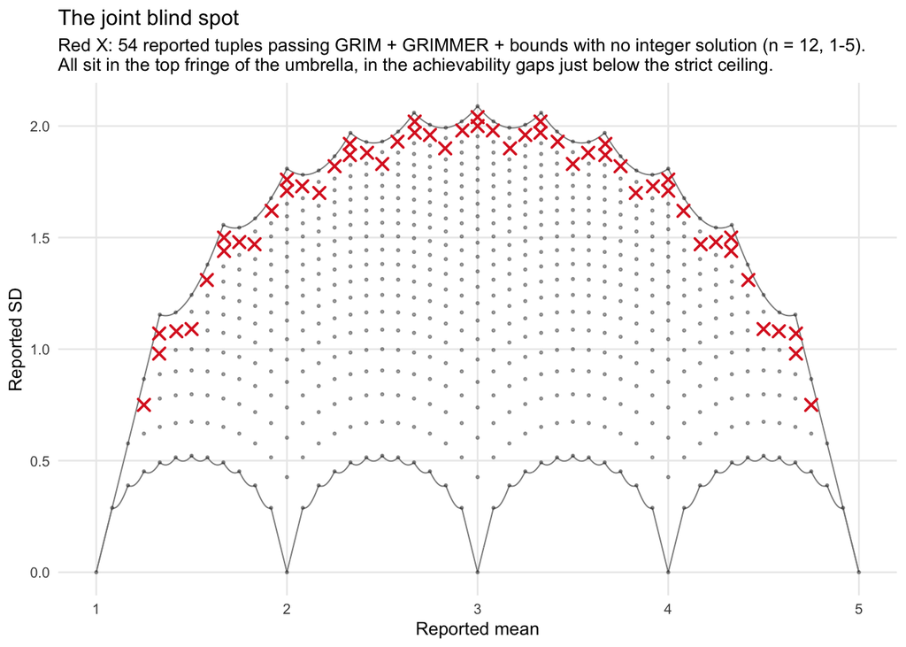

```r
ggplot() +
  geom_line(data = grid_env, aes(mean, hi), colour = "grey55", linewidth = 0.35) +
  geom_line(data = grid_env, aes(mean, lo), colour = "grey55", linewidth = 0.35) +
  geom_point(data = umbrella, aes(mean, sd), size = 0.5, alpha = 0.35) +
  geom_point(data = false_pass, aes(m2, s2), colour = "#dc2626", shape = 4,
             size = 2.4, stroke = 1) +
  scale_x_continuous("Reported mean", breaks = l_u:u_u) +
  scale_y_continuous("Reported SD") +
  labs(title = "The joint blind spot",
       subtitle = sprintf("Red X: %d reported tuples passing GRIM + GRIMMER + bounds with no integer solution (n = %d, %d-%d).\nAll sit in the top fringe of the umbrella, in the achievability gaps just below the strict ceiling.",
                          nrow(false_pass), n_u, l_u, u_u)) +
  theme_minimal(base_size = 10) +
  theme(panel.grid.minor = element_blank())
```

**Reading.** The red crosses are the residual: tuples no *closed-form* test in the battery can catch. They are structural, not implementation bugs — each test is correct about its own shadow of the problem. Closing them requires joint achievability of (sum, sum of squares) within the limits. Their scarcity and predictable location (the top ~15% of the umbrella’s height, hugging the ceiling) is itself useful: a reported value that passes everything *and* sits close to the mean-conditional maximum is exactly the case worth certifying exactly.

## Closing the blind spot: `brimmest()`

`brimmest()` settles the residual. It obtains the same joint achievability the enumeration above does, but by dynamic programming over the reachable (sum, sum of squares) states rather than by materialising datasets, so no sample is ever constructed and the cost depends only on $(l, u, n)$ rather than on how many datasets exist. Three claims, each checked against an independent oracle.

```r
res_cert <- list()

# (i) against the Part 2 composition enumeration: two different algorithms
# (compositions of n over the scale points vs. a reachability DP) must induce
# the same set of reportable tuples once rounded to the reporting grid
enum_key <- unique(unlist(lapply(c("half_up", "half_down"), function(rr)
  paste(round(strait:::.round_reported(umbrella$mean, 1, rr) * 10),
        round(strait:::.round_reported(umbrella$sd,   1, rr) * 10)))))
grid_c <- expand.grid(mean = seq(l_u, u_u, by = 0.1),
                      sd   = seq(0, ceiling(sd_max_span_n(l_u, u_u, n_u) * 10) / 10,
                                 by = 0.1))
cert_c <- brimmest(l = l_u, u = u_u, n = n_u,
                  mean = grid_c$mean, sd = grid_c$sd, digits = 1)
res_cert[["brimmest() == composition enumeration, cell for cell"]] <-
  identical(cert_c$possible,
            paste(round(grid_c$mean * 10), round(grid_c$sd * 10)) %in% enum_key)

# (ii) against CLOSURE, cell for cell, on a smaller design
um_cl <- umbrella_data(n = 9, l = 1, u = 5, digits = 1, Z = "integer")
cert_cl <- brimmest(l = 1, u = 5, n = 9, mean = um_cl$mean, sd = um_cl$sd,
                   digits = 1)
closure_cl <- vapply(seq_len(nrow(um_cl)), function(i) {
  r <- try(suppressWarnings(unsum::closure_generate(
    mean = sprintf("%.1f", um_cl$mean[i]), sd = sprintf("%.1f", um_cl$sd[i]),
    n = 9, scale_min = 1, scale_max = 5, rounding = "up_or_down")),
    silent = TRUE)
  if (inherits(r, "try-error")) FALSE else nrow(r$results) > 0
}, logical(1))
res_cert[["brimmest() == unsum::CLOSURE, cell for cell"]] <-
  identical(cert_cl$possible, closure_cl)

# (iii) the closed-form screen is NECESSARY but not sufficient: it must never
# reject a tuple brimmest() proves attainable, while brimmest() rejects exactly
# the blind-spot cells it admits
res_cert[["screen never rejects a certified-attainable tuple"]] <-
  sum(!um_cl$consistent & cert_cl$possible) == 0
res_cert[["brimmest() rejects blind-spot cells the screen admits"]] <-
  sum(um_cl$consistent & !cert_cl$possible) > 0

for (nm in names(res_cert)) check(res_cert[[nm]], nm)
kable(tibble(test = names(res_cert), passed = unlist(res_cert)),
      caption = "brimmest(): the analytic CLOSURE certificate.")
```

brimmest(): the analytic CLOSURE certificate.

| test | passed |
| --- | --- |
| brimmest() == composition enumeration, cell for cell | TRUE |
| brimmest() == unsum::CLOSURE, cell for cell | TRUE |
| screen never rejects a certified-attainable tuple | TRUE |
| brimmest() rejects blind-spot cells the screen admits | TRUE |

The blind spot is therefore no longer a limitation of the package, only of the closed-form layer within it. `brimmer()` remains the fast screen; `brimmest()` is the exact adjudicator for whatever survives it.

# Part 4: multi-item scoring, POMP, and the derived builders

The `scoring`/`n_items` layer, the POMP transforms of `brimmer()`, and the derived `brimmer_multiple()` / `sd_bounds_curve()` / `umbrella_data()` builders each carry their own validated claim.

## Multi-item granularity: the affine invariance

Mean-scored data on `n_items = m` items live on a `1/m` grid. Under `w = m x` that grid becomes the integers, so every bound must equal the single-item bound computed on the scaled scale, divided by `m`. This is checked directly against exhaustive enumeration of `m`-item integer response profiles (whose per-person means populate the `1/m` grid), not merely against the scaled formula, so it certifies the affine reduction end to end.

```r
# exhaustive: n people, each a mean of m integer items in [il, iu]
aff_bad <- 0; aff_cells <- 0
for (m in 2:3) for (n in c(3, 4)) {
  il <- 1; iu <- 3
  # every profile of n*m item responses; per person = mean of its m items
  G <- as.matrix(do.call(expand.grid, rep(list(il:iu), n * m)))
  # per-person means: average consecutive blocks of m columns
  pm <- sapply(seq_len(n), function(p) rowMeans(G[, ((p - 1) * m + 1):(p * m), drop = FALSE]))
  personmean <- pm                              # rows = profiles, cols = people
  grand <- rowMeans(personmean)
  sdv   <- apply(personmean, 1, sd)
  for (M in sort(unique(round(grand, 12)))) {
    i <- abs(grand - M) < 1e-9
    aff_cells <- aff_cells + 1
    r <- sd_bounds(l = il, u = iu, n = n, mean = M, Z = "integer",
                   scoring = "meanscored", n_items = m)
    if (!(r$feasible &&
          abs(r$min_sd - min(sdv[i])) < 1e-9 &&
          abs(r$max_sd - max(sdv[i])) < 1e-9)) aff_bad <- aff_bad + 1
    # and equals the single-item bound on the w = m*x scale, / m
    r2 <- sd_bounds(l = il * m, u = iu * m, n = n, mean = M * m, Z = "integer")
    if (abs(r$min_sd - r2$min_sd / m) > 1e-9 ||
        abs(r$max_sd - r2$max_sd / m) > 1e-9) aff_bad <- aff_bad + 1
  }
}
check(aff_bad == 0, sprintf("meanscored bounds == enumeration & affine reduction (%d cells)", aff_cells))

# mean-scored composite with alpha == sum-scored composite on the w scale, / m
m <- 4
ma <- sd_bounds(l = 1, u = 5, n = 25, mean = 3.2, Z = "integer",
                scoring = "meanscored", n_items = m, alpha = 0.75)
sa <- sd_bounds(l = 1 * m, u = 5 * m, n = 25, mean = 3.2 * m, Z = "integer",
                scoring = "sumscored", n_items = m, alpha = 0.75)
check(isTRUE(all.equal(c(ma$min_sd, ma$max_sd), c(sa$min_sd, sa$max_sd) / m)),
      "meanscored+alpha == sumscored+alpha / n_items")

# singleitem forbids alpha and n_items > 1
guard_ok <-
  inherits(try(sd_bounds(l = 1, u = 5, n = 9, mean = 3, alpha = 0.7,
                         scoring = "singleitem"), silent = TRUE), "try-error") &&
  inherits(try(sd_bounds(scoring = "singleitem", n_items = 2), silent = TRUE), "try-error")
check(guard_ok, "singleitem rejects alpha and n_items > 1")

kable(tibble(test = c("affine invariance", "meanscored+alpha reduction", "singleitem guards"),
             passed = c(aff_bad == 0,
                        isTRUE(all.equal(c(ma$min_sd, ma$max_sd), c(sa$min_sd, sa$max_sd) / m)),
                        guard_ok)),
      caption = "Multi-item scoring layer.")
```

Multi-item scoring layer.

| test | passed |
| --- | --- |
| affine invariance | TRUE |
| meanscored+alpha reduction | TRUE |
| singleitem guards | TRUE |

## POMP transforms

`pomp_sd_parity` is a linear rescaling by the mean-agnostic parity ceiling (so it doubles when the SD doubles and never depends on the mean); `pomp_sd_sharp` places the SD inside the sharp mean-conditional band actually returned, so it is exactly 1 at a witnessed maximum-SD configuration and exactly 0 at the floor.

```r
# parity is linear and mean-independent
p1 <- brimmer(l = 1, u = 7, n = 30, mean = 4, sd = 1.0, sd_digits = 6,
                      rounding = NULL, Z = "continuous")
p2 <- brimmer(l = 1, u = 7, n = 30, mean = 4, sd = 2.0, sd_digits = 6,
                      rounding = NULL, Z = "continuous")
p3 <- brimmer(l = 1, u = 7, n = 30, mean = 6, sd = 1.0, sd_digits = 6,
                      rounding = NULL, Z = "continuous")
lin  <- abs(p2$pomp_sd_parity - 2 * p1$pomp_sd_parity) < 1e-9
mind <- abs(p3$pomp_sd_parity - p1$pomp_sd_parity) < 1e-9   # same s, different mean

# sharp == 1 at the ceiling, 0 at the floor
mxc <- sd_bounds(l = 1, u = 5, n = 9, mean = 3)$max_sd
mnc <- sd_bounds(l = 1, u = 5, n = 9, mean = 2.44, Z = "quasiinteger")$min_sd
sh1 <- brimmer(l = 1, u = 5, n = 9, mean = 3, sd = mxc, sd_digits = 9,
                       rounding = NULL, Z = "continuous")$pomp_sd_sharp
sh0 <- brimmer(l = 1, u = 5, n = 9, mean = 2.44, sd = mnc, sd_digits = 9,
                       rounding = NULL, Z = "quasiinteger")$pomp_sd_sharp
sharp_ok <- abs(sh1 - 1) < 1e-6 && abs(sh0 - 0) < 1e-6

check(lin && mind, "pomp_sd_parity is linear and mean-independent")
check(sharp_ok, "pomp_sd_sharp is 1 at the ceiling and 0 at the floor")
kable(tibble(test = c("parity linear", "parity mean-independent",
                      "sharp=1 at ceiling", "sharp=0 at floor"),
             passed = c(lin, mind, abs(sh1 - 1) < 1e-6, abs(sh0) < 1e-6)),
      caption = "POMP transforms.")
```

POMP transforms.

| test | passed |
| --- | --- |
| parity linear | TRUE |
| parity mean-independent | TRUE |
| sharp=1 at ceiling | TRUE |
| sharp=0 at floor | TRUE |

## Derived builders

`brimmer_multiple()` must equal a row-wise loop (its de-duplication is an optimisation, not a semantic change); `sd_bounds_curve()` must be hole-free under a granularity relaxation; and `umbrella_data()`’s passing set must match an independent GRIM + GRIMMER + bounds screen.

```r
# check_multiple == row-wise, on a grid that includes duplicate tuples
df <- expand.grid(mean = c(2.90, 2.97, 3.50), sd = c(0.10, 1.50, 2.83))
df <- rbind(df, df[1:3, ])                       # force duplicates
mult <- brimmer_multiple(df, l = 1, u = 7, n = 30, mean_digits = 2,
                                 sd_digits = 2, Z = "integer")
roww <- do.call(rbind, lapply(seq_len(nrow(df)), function(i)
  brimmer(l = 1, u = 7, n = 30, mean = df$mean[i], mean_digits = 2,
                  sd = df$sd[i], sd_digits = 2, Z = "integer")))
mult_ok <- isTRUE(all.equal(mult$consistent, roww$consistent)) &&
           isTRUE(all.equal(mult$min_sd, roww$min_sd)) &&
           isTRUE(all.equal(mult$pomp_sd_sharp, roww$pomp_sd_sharp))

# curve hole-free under quasi-integer
cv <- sd_bounds_curve(l = 1, u = 7, n = 30, Z = "quasiinteger")
curve_ok <- !any(is.na(cv$min_sd[cv$feasible])) && !any(is.na(cv$max_sd[cv$feasible]))

# umbrella passing set == independent screen
um <- umbrella_data(n = 12, l = 1, u = 7, digits = 2)
indep <- with(um, {
  gm <- as.logical(scrutiny::grimmer(x = mean, sd = sd, n = 12, digits_x = 2,
                                     digits_sd = 2, items = 1, rounding = "up_or_down"))
  ib <- (sd + 0.005) >= min_sd - 1e-9 & (sd - 0.005) <= max_sd + 1e-9
  gm & ib
})
umb_ok <- isTRUE(all.equal(um$consistent, indep))

check(mult_ok, "brimmer_multiple == row-wise loop")
check(curve_ok, "sd_bounds_curve is hole-free under quasi-integer")
check(umb_ok, "umbrella_data passing set == independent GRIMMER + bounds screen")
kable(tibble(test = c("check_multiple == row-wise", "curve hole-free",
                      "umbrella == independent screen"),
             passed = c(mult_ok, curve_ok, umb_ok)),
      caption = "Derived builders.")
```

Derived builders.

| test | passed |
| --- | --- |
| check_multiple == row-wise | TRUE |
| curve hole-free | TRUE |
| umbrella == independent screen | TRUE |

# Part 5: the sharp alpha-conditional floor (Gini envelope, Theorem H5)

Under a reported Cronbach’s alpha the amplified floor of Theorem H4 vanishes at whole-number sum-score means, yet a defined positive alpha makes a constant composite impossible (its alpha is `0/0`) and excludes the two-adjacent-value profiles that give the alpha-free minimum. The sharp floor is the Gini envelope of Theorem H5: the least composite SD among integer profiles whose design-factor cap `m_max(S) = n * SS_S / V_min(S)` reaches the reported design factor. It must (i) reproduce the article’s disproof counterexample, (ii) be a valid lower bound and sharp against brute force, and (iii) lift the floor off zero at whole-number means where the amplified floor is zero.

```r
# (i) the disproof composite {0, 3,3,3, 4x10}, n = 14: SS_S = 15.5, m_max = 2.7468
env_disproof <- strait:::sd_min_alpha_gini(l = 0, u = 4, n = 14, mean = 3.5, m = 2.7468)
disproof_ok <- isTRUE(all.equal(env_disproof, sqrt(15.5 / 13), tolerance = 1e-6))

# (ii) exhaustive: n = 4 people, k = 2 integer items in 1..3
n <- 4; k <- 2; il <- 1; iu <- 3
G <- as.matrix(expand.grid(rep(list(il:iu), n * k)))
person  <- ((seq_len(n * k) - 1) %/% k) + 1
itemidx <- ((seq_len(n * k) - 1) %%  k) + 1
comp <- sapply(1:n, function(p) rowSums(G[, person == p, drop = FALSE]))
compmean <- rowMeans(comp)
SS_S <- rowSums((comp - compmean)^2)
V <- rowSums(sapply(1:k, function(it) {
  Xi <- G[, itemidx == it, drop = FALSE]; apply(Xi, 1, function(r) sum((r - mean(r))^2))
}))
m_d <- ifelse(V > 0, SS_S / V, Inf); sd_d <- sqrt(SS_S / (n - 1))
viol <- 0L
for (i in which(V > 1e-9 & SS_S > 1e-9)) {
  e <- strait:::sd_min_alpha_gini(l = k * il, u = k * iu, n = n, mean = compmean[i], m = m_d[i])
  if (!is.null(e) && e > sd_d[i] + 1e-9) viol <- viol + 1L
}
valid_ok <- viol == 0L
mu0 <- k * 2
sharp_ok <- all(vapply(c(1.2, 1.5, 2.0), function(mt) {
  cand <- which(abs(compmean - mu0) < 1e-9 & m_d >= mt - 1e-9 & SS_S > 1e-9)
  isTRUE(all.equal(strait:::sd_min_alpha_gini(l = k * il, u = k * iu, n = n, mean = mu0, m = mt),
                   min(sd_d[cand]), tolerance = 1e-9))
}, logical(1)))

# (iii) positive at a whole-number mean where the amplified floor is zero
amped <- sd_bounds(l = 0, u = 3, n = 10, mean = 1.5, Z = "integer",
                   scoring = "meanscored", n_items = 2)
withA <- sd_bounds(l = 0, u = 3, n = 10, mean = 1.5, Z = "integer",
                   scoring = "meanscored", n_items = 2, alpha = 0.7)
lift_ok <- amped$min_sd == 0 && withA$min_sd > 0 && grepl("Gini", withA$min_rule)

# (iv) unaffordable window falls back to the proven floor, flagged
fb <- sd_bounds(l = 1, u = 5, n = 20, mean = 3, Z = "integer",
                scoring = "meanscored", n_items = 3, alpha = 0.8)
fallback_ok <- isTRUE(fb$feasible) && !is.na(fb$note) && grepl("not evaluated", fb$note)

check(disproof_ok, "Gini envelope reproduces the disproof counterexample")
check(valid_ok,    "Gini envelope is a valid lower bound (brute force, 0 violations)")
check(sharp_ok,    "Gini envelope is sharp at whole-number means (brute force)")
check(lift_ok,     "positive alpha lifts the floor off zero at a whole-number mean")
check(fallback_ok, "over-budget composite window falls back to the proven floor with a note")
kable(tibble(test = c("disproof reproduced", "valid lower bound", "sharp vs brute",
                      "lifted off zero", "graceful fallback"),
             passed = c(disproof_ok, valid_ok, sharp_ok, lift_ok, fallback_ok)),
      caption = "Sharp alpha-conditional floor (Gini envelope).")
```

Sharp alpha-conditional floor (Gini envelope).

| test | passed |
| --- | --- |
| disproof reproduced | TRUE |
| valid lower bound | TRUE |
| sharp vs brute | TRUE |
| lifted off zero | TRUE |
| graceful fallback | TRUE |

# Validation claimed by the JOSS paper

`paper/paper.md` makes specific claims about what has been validated and how. Each is discharged by a section above; this table is the crosswalk, so that a reviewer can go from a sentence in the paper to the check that supports it.

| Claim in `paper/paper.md` | Where it is validated |
| --- | --- |
| “validated against exhaustive enumeration” | Part 1, exact path vs exhaustive enumeration; Part 2, the composition enumeration of every frequency vector for $(n, l, u)$ |
| “and, for the tuples that pass every test, against the CLOSURE algorithm implemented in `unsum`” | Part 3, the joint blind spot, and `brimmest()` vs CLOSURE cell for cell |
| bounds are **sharp**, not merely valid | Part 2, ceiling and floor *attained* at every attainable mean |
| “an out-of-bounds verdict is a proof of impossibility rather than the outcome of an enumeration” | Part 1, rounding envelopes; Part 3, the screen never rejects a certified-attainable tuple |
| GRIM and GRIMMER “deferred … rather than reimplemented” | Part 1, scrutiny deference, including both false-flag witnesses |
| the alpha-conditional floor is sharp for integer composites (Theorem H5) | Part 5, the Gini envelope |
| multi-item scoring behaves as an affine rescaling | Part 4, the affine invariance |

```r
summary_tbl <- tibble(check = names(ok_tally), passed = unlist(ok_tally))
kable(summary_tbl, caption = "All validation checks in this document.")
```

All validation checks in this document.

| check | passed |
| --- | --- |
| exact path == enumeration (648 cells) | TRUE |
| quasiinteger envelope | TRUE |
| continuous envelope | TRUE |
| closed endpoints (up_or_down) | TRUE |
| open upper endpoint (up) | TRUE |
| open lower endpoint (down) | TRUE |
| trunc interval [x, x+unit) | TRUE |
| witness: feasible & sd_in_bounds TRUE | TRUE |
| witness: scrutiny grimmer FALSE (documented false flag) | TRUE |
| sd above ceiling: sd_in_bounds FALSE | TRUE |
| documented grim false pass surfaces divergence note | TRUE |
| brimmest() admits a hand-constructed integer witness | TRUE |
| brimmer verdict paths | TRUE |
| umbrella inside [integer floor, Structure S ceiling] | TRUE |
| Structure S ceiling ATTAINED at every attainable mean (sharp above) | TRUE |
| integer floor ATTAINED at every attainable mean (sharp below) | TRUE |
| no false flags (truth achievable but some test fails) | TRUE |
| false passes exist (the blind spot is real) | TRUE |
| false passes are few (< 10% of passing tuples; ~8% at this coarse n) | TRUE |
| all false passes in the top fringe (relative height > 0.75) | TRUE |
| no false pass exceeds the strict achievable maximum at its mean | TRUE |
| ladder band retains every false pass (pruning is safe) | TRUE |
| CLOSURE confirms all 54 false passes have no integer solution | TRUE |
| CLOSURE confirms every near-ceiling achievable tuple has >= 1 solution | TRUE |
| spot-check outside the band: all achievable (nothing hidden) | TRUE |
| brimmest() == composition enumeration, cell for cell | TRUE |
| brimmest() == unsum::CLOSURE, cell for cell | TRUE |
| screen never rejects a certified-attainable tuple | TRUE |
| brimmest() rejects blind-spot cells the screen admits | TRUE |
| meanscored bounds == enumeration & affine reduction (74 cells) | TRUE |
| meanscored+alpha == sumscored+alpha / n_items | TRUE |
| singleitem rejects alpha and n_items > 1 | TRUE |
| pomp_sd_parity is linear and mean-independent | TRUE |
| pomp_sd_sharp is 1 at the ceiling and 0 at the floor | TRUE |
| brimmer_multiple == row-wise loop | TRUE |
| sd_bounds_curve is hole-free under quasi-integer | TRUE |
| umbrella_data passing set == independent GRIMMER + bounds screen | TRUE |
| Gini envelope reproduces the disproof counterexample | TRUE |
| Gini envelope is a valid lower bound (brute force, 0 violations) | TRUE |
| Gini envelope is sharp at whole-number means (brute force) | TRUE |
| positive alpha lifts the floor off zero at a whole-number mean | TRUE |
| over-budget composite window falls back to the proven floor with a note | TRUE |

```r
stopifnot(all(summary_tbl$passed))
```